# Gender Inequality Dashborad

User manual / short report

Msc in Digital Marketing & Data Science, Ya-Hsuan TAI

## Information

### Link

This dashboard is made with R shiny (shinydashboard).  
Here’s the link to the dashboard: https://ivdaae.shinyapps.io/Gender_Inequality_Dashboard/

### Data source

The datasets I use for this dashboard is from [OECD Gender Data Portal](https://www.oecd.org/gender/), which includes selected indicators shedding light on gender inequalities in employment, development and governance, showing how far we are from achieving gender equality and where actions is most needed.

The data covers OECD member countries, as well as partner economies including Brazil, China, India, Indonesia, and South Africa.

For the dashboard, I extracted the data of employment, development and governance, and then compiled it into one file: **gender_ineq.RData**.

## Purpose

#### A story-telling of gender inequality

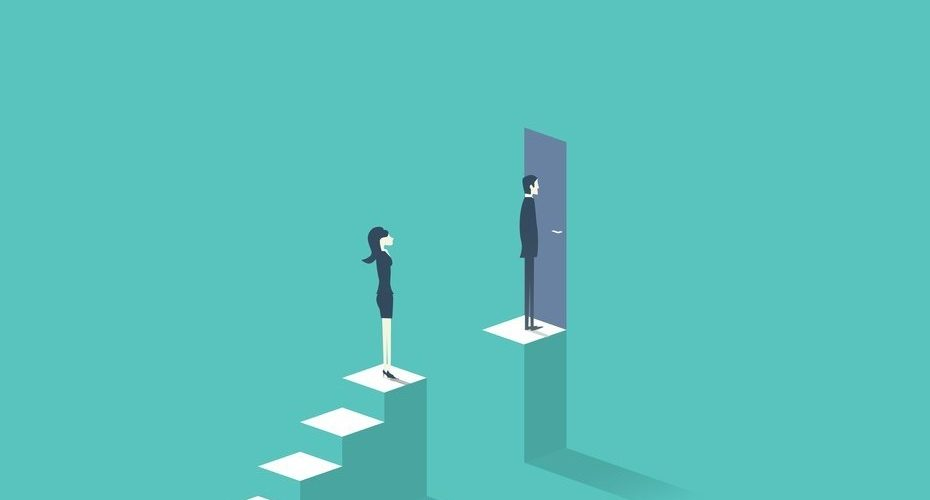

Even until this year 2019, gender inequality is still a huge main problem in the world. However, people are not aware of this problem or not convinced by the feminists, because of the fact that most of the arguments about gender inequality are not supported by data, which made the feminists argument vague and unconvincing.

Hence, I would like to tell the whole story of gender inequality through this dashboard in various aspects: employment, development and governance.

The goal is to give people a clear understanding of the current situation of gender inequality happening all over the world.

## User Guide

### Short description

This dashboard is about **“gender inequality”**, which shows the gender inequality in 3 aspects: governance, development and employment.

There are four sections in this dashboard:

1. The header, which is the name of the dashboard: “Gender Inequality Dashboard”.
2. The sidebar, in which the user can input year range, gender (men and women), and max number of countries for each aspects.
3. The upper part of the body, which contains some main figures about current gender inequality situation in the world.
4. The bottom part of the body, which contains graphs and tables of the three aspects mentioned above.

Here’s the outlook of the dashboard:

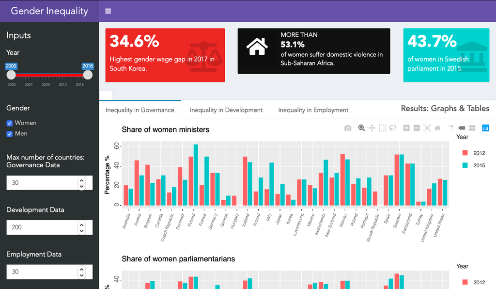

### Interact with the dashboard

#### How to interact with the dashboard?

In order to interact with the dashboard, you can go to the sidebar **Inputs** section.

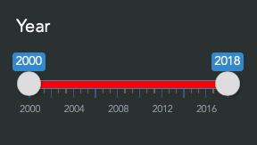

Also, in **Gender** section, you can choose which gender to show in the graghs and tables. **IMPORTANT**: This is only useful in the **Employment** part, since the data of other parts doesn’t include gender variable.

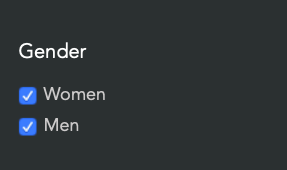

In **Max number of countries** section, you can specify the number of countries you would like to see in the dashboard. I have separated the section into each of the 3 aspects, since the amount of countries in each datasets is different, especially for **Development** section, which needs larger number of countries to have a better violin graph.

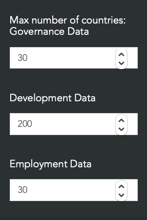

### Key figures

#### Where can I find the key figures of gender inequality?

You can find the key figures of current situation of gender inequality on the top of the dashboard.

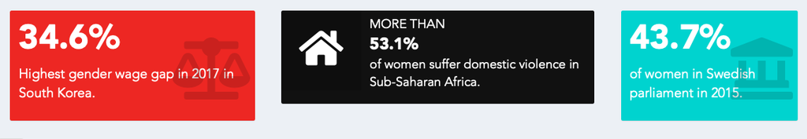

I’ve created three boxes containing key figures in the dashboard, each box for each aspect.

The first box shows the employment key figures: the country which has the highest wage gap in 2017 – **South Korea**. Gender wage gap refers to **the wage difference between men and women**. Hence, it is indicated that there is still much space of improvement of gender inequality in workspace in South Korea.

The second box shows the development key figures: the region which has the highest women prevalence of violence in the lifetime – **Sub-Saharan Area**. It refers to the fact that there are still many women suffering from domestic violence in this area, which should be improved by the efforts of NGO, law framework, and the government.

The third box shows the governance key figures: the country which has the highest share of women in parliament in 2015 – **Sweden**. It refers to the fact that there are 43% women in parliament in Sweden, which is the highest above all the countries in the data, which is a big step for gender equality.

### Graphs & Tables

#### How can I see the graphs? What does the graphs mean?

You can see the graghs in the bottom part of the dashboard - **Results: Graphs & Tables**. Each tab contains some graphs and a pivot table at the bottom of the page. There are three tab: *Inequality in Governance, Inequality in Development, Inequality in Employment*.

You can interact with the graphs and the tables by modifying the factors in **Sidebar** section.

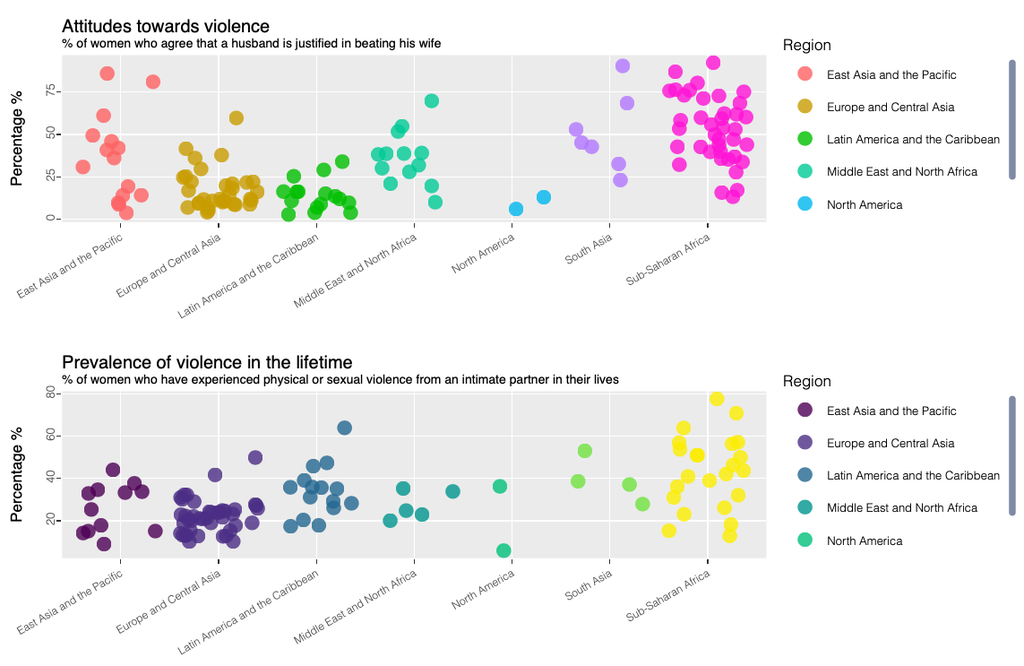

The pivot tables are at the bottom of the page in each section. For example, the pivot table you find in Governance section, you can see the average value of each country and indicators.

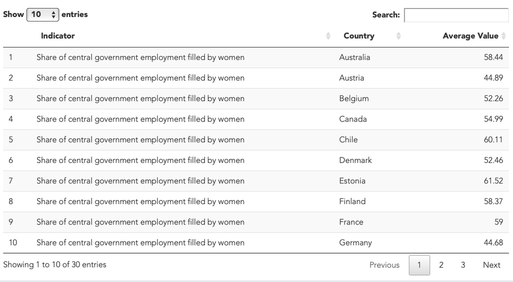

## Future Improvements

Although the dashboard is complete and informative, I would like to add some improvements in the future:

1. enrich the section **Employment** with more graphs
2. improve the pivot tables to make them more insightful
3. add **word cloud** and **emotion analysis** into the dashboard by webcrawling the words related to gender inequality on social media

## Contact

If you have further questions or suggestions, please contact me via yahsuan.tai@edu.em-lyon.com.